# Patterns of Caregiver Aggressive and Nonaggressive Discipline Toward Young Children in Low- and Middle-Income Countries:

A Latent Class Approach

Kaitlin P. Ward, Shawna J. Lee, Andrew C. Grogan-Kaylor, Julie Ma, Garrett T. Pace

2022-03-07

# 1 Background

Caregivers use a variety of disciplinary methods to respond to undesired child behavior. Many caregivers use nonaggressive forms of discipline, such as verbal reasoning and redirection. Some caregivers use aggressive forms of discipline, such as spanking and yelling. However, most caregivers use a combination of aggressive and nonaggressive discipline. To date, a disproportionately small number of caregiver discipline studies are conducted in low- and middle-income countries (LMICs), and few studies in low-resource contexts examine aggressive and nonaggressive behaviors simultaneously.

# 2 Plots

You may include any number of plots in a section.

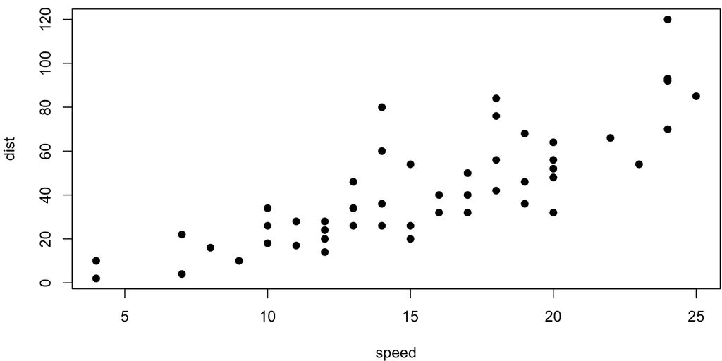

Figure 2.1: A boring scatterplot.

```r
par(mar = c(4, 4, .5, .1))
plot(cars, pch = 19)
```

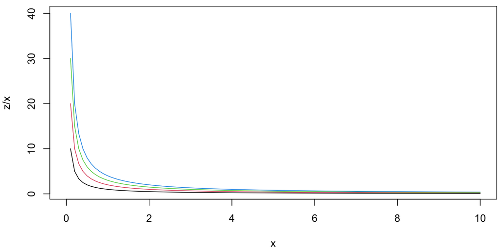

Figure 2.2: A series of curves.

```r
for (z in 4:1) curve(z/x, 0, 10, add = z < 4, col = z)
```

# 3 Images

Local news [reported](https://www.desmoinesregister.com/story/news/2018/04/27/rubber-duck-des-moines-yess-duck-derby/558852002/) a giant inflatable rubber duck rolling down the street of Des Moines, where this package is conceived.

[figure not shown]

The Rolling Duck

# 4 Videos

You can also embed videos here.

[video not shown]

# 5 Technical details

The current implementation of this sidebar layout is kind of cumbersome. The HTML template is `rolldown:::pkg_resource('html', 'scrollama-side.html')`. We have hard-coded some CSS and JavaScript code in this template, which means, for example, you cannot easily customize the initialization of Scrollama (if you really want to, you must provide your own HTML template). You should be free to customize CSS, though (like we did in the beginning of this example document).

Activating sections doesn’t work well (especially in RStudio Viewer). We don’t know why at the moment.